# Biostatisitk R-Seminar: Gruppenaufgaben

Erik Fuhrmann

2023-07-02

Laden benötigter Packages für kommende Aufgaben:

```r
packages_benoetigt <- c("ggplot2", "reshape2", "car")
packages_neu <- packages_benoetigt[!(packages_benoetigt %in% installed.packages()[,"Package"])]
if(length(packages_neu)) install.packages(packages_neu)
lapply(packages_benoetigt, require, character.only = TRUE)
```

## Aufgabe A - Statistisches Testen von Biomarkern unter Berücksichtigung des multiplen Testens

#### **1. Selektieren Sie die Daten für Ihre Fragestellung aus dem Datensatz!**

Mit folgendem Code wird der Datensatz eingelesen und auf die benötigten Werte begrenzt:

```r
# Der Datensatz liegt hier im Arbeitsverzeichnis vor.
daten_biomarker_vollst <- read.csv2("data_subset_breast_tumor.csv")

# Auswahl von Daten Tumorgrad 1/3 + Biomarker
daten_biomarker <- daten_biomarker_vollst[daten_biomarker_vollst$grade != 2, 4:10]
```

Der Datensatz sieht dann so aus (ersten Zeilen):

```
##    grade X1007_s_at X1053_at  X117_at  X121_at X1255_g_at X1294_at
## 2      3   12.86058 8.656013 7.702192 9.586913   5.610451 8.399767
## 3      3   12.04763 8.592693 7.479278 9.297300   4.588868 8.884104
## 8      3   11.56528 8.904414 7.499551 9.061995   4.100552 8.493093
## 10     1   11.72588 8.151481 4.240336 9.300117   5.008374 9.568747
## 16     3   11.69231 8.679955 8.483382 8.722111   2.907951 8.557537
## 21     1   11.16250 8.494755 6.952299 9.448791   4.767867 8.848641
```

#### **2. Berechnen Sie für die beiden Tumorgradgruppen Mittelwerte und Standardabweichungen zu den 6 Biomarkern!**

Es werden die Funktionen `mean()` und `sd()` verwendet.

```r
biomarker_diskriptiva <- data.frame()

# Berechnung der Mittelwerte und Standardabweichung
for (i in 1:2){
  for (j in 1:6){
  biomarker_diskriptiva[j+6*(i-1), 1] <- round(mean(daten_biomarker[daten_biomarker$grade == (1+2*(i-1)), j+1]),
                                       digits = 2)
  biomarker_diskriptiva[j+6*(i-1), 2] <- round(sd(daten_biomarker[daten_biomarker$grade == (1+2*(i-1)), j+1]),
                                       digits = 2)
  row.names(biomarker_diskriptiva)[j+6*(i-1)] <- paste("Grad ", (1+2*(i-1)), ", ",
                                                       colnames(daten_biomarker)[j+1], sep = "")
  }
}

colnames(biomarker_diskriptiva) <- c("arith. Mittel", "SD")
biomarker_diskriptiva
```

```
##                    arith. Mittel   SD
## Grad 1, X1007_s_at         11.87 0.34
## Grad 1, X1053_at            8.37 0.44
## Grad 1, X117_at             7.37 0.77
## Grad 1, X121_at             9.77 0.34
## Grad 1, X1255_g_at          5.03 0.99
## Grad 1, X1294_at            9.31 0.47
## Grad 3, X1007_s_at         11.87 0.52
## Grad 3, X1053_at            9.12 0.54
## Grad 3, X117_at             7.79 0.51
## Grad 3, X121_at             9.72 0.37
## Grad 3, X1255_g_at          4.66 1.40
## Grad 3, X1294_at            8.79 0.52
```

Die gerundeten Mittelwerte und Standardabweichungen sind der obigen Tabelle zu entnehmen.

#### **3. Erstellen Sie 6 gruppierte Boxplots in einer Grafik!**

`ggplot()` zur Visualisierung:

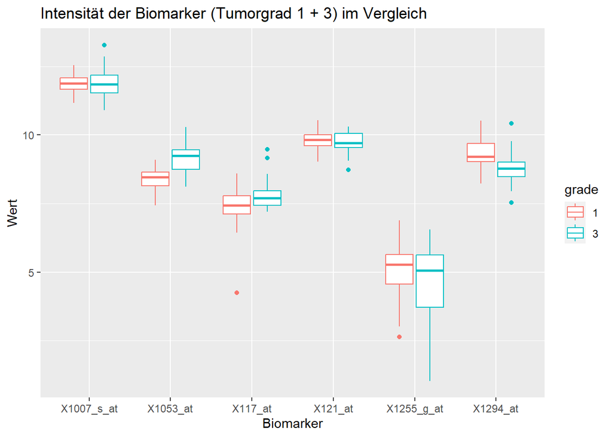

```r
daten_biomarker$grade <- as.factor(daten_biomarker$grade)

# Das DataFrame lässt sich alternativ auch ohne reshape2::melt umstellen, ist nur etwas länger
# (beispielsweise in Aufgabe B-4 so durchgeführt)
ggplot(melt(daten_biomarker, id.vars = "grade",variable.name = "Biomarker", value.name = "Wert"),
       aes(x = Biomarker, y = Wert, color = grade)) +
  geom_boxplot() +
  labs(title = "Intensität der Biomarker (Tumorgrad 1 + 3) im Vergleich")
```

Obige Graphik zeigt jeweils die 6 gruppierten Boxplots, unterteilt nach Biomarker und Tumorgrad.

#### **4. Führen Sie die 6 t-Tests zum Vergleich der Expression der Biomarker durch!**

Da die Variante des t-Tests nicht vorgegeben ist, wird hier der Welch’s t-Test ausgewählt. Weil vorher nicht auf Varianzhomogenität getestet wurde, wäre ein Student’s t-Test fehleranfälliger. Darüber hinaus verhält sich der Welch’s t-Test für rein varianzhomogene Daten ohnehin wie der Student’s t-Test. Das Signifikanzniveau wird auf $\alpha = 0.05$ gesetzt. Zur Verwendung des Welch’s t-Test wird für die Funktion `t.test()` der Parameter `var.egual = FALSE` gesetzt.

```r
biomarker_p_t_tests <- data.frame()

# Welch's t-tests für alle 6 Biomarker
for (i in 1:6){
  biomarker_p_t_tests[i, 1] <- round(t.test(daten_biomarker[, i+1] ~ daten_biomarker$grade,
                                          var.equal = FALSE)$p.value,
                                   digits = 4)
  row.names(biomarker_p_t_tests)[i] <- colnames(daten_biomarker)[i+1]
  if (biomarker_p_t_tests[i, 1] < 0.05){
    biomarker_p_t_tests[i, 2] <- "*"
  } else {
    biomarker_p_t_tests[i, 2] <- ""
  }
}
colnames(biomarker_p_t_tests) <- c("p-Wert", "Signifikanz (Welch)")

biomarker_p_t_tests
```

```
##            p-Wert Signifikanz (Welch)
## X1007_s_at 0.9750
## X1053_at   0.0000                   *
## X117_at    0.0150                   *
## X121_at    0.6187
## X1255_g_at 0.2217
## X1294_at   0.0001                   *
```

In der Tabelle sind die gerundeten p-Werte der jeweiligen Welch’s t-Tests abzulesen.

Randnotiz: Eine Varianzuntersuchung (mittels `car::leveneTest()`) bestätigt tatsächlich, dass nicht alle Gruppen Varianzhomogen sind sind (s. *X1007_s_at*):

```r
# Testung auf Varianzgleichheit der beiden Gruppen (Levene's Test)
biomarker_p_levene <- data.frame()

for (i in 1:6){
  biomarker_p_levene[i, 1] <- round(leveneTest(daten_biomarker[, i+1], daten_biomarker$grade)$`Pr(>F)`[1],
                                      digits = 4)
  row.names(biomarker_p_levene)[i] <- colnames(daten_biomarker)[i+1]
}
colnames(biomarker_p_levene) <- "p-Wert (Levene's Test)"
biomarker_p_levene
```

```
##            p-Wert (Levene's Test)
## X1007_s_at                 0.0256
## X1053_at                   0.2700
## X117_at                    0.2547
## X121_at                    0.5744
## X1255_g_at                 0.1126
## X1294_at                   0.8318
```

Da $p_{X1007\_s\_at} < 0.5$ wird die Nullhypothese H0 (Homoskedastizität) verworfen.

#### **5. Adjustieren Sie die p-Werte mit unterschiedlichen Prozeduren für multiples Testen.**

Für die Adjustierung von p-Werten aufgrund multiplen Testens gibt es verschiedene Korrekturverfahren. Einige sollen hier angewendet werden. Der Übersichtlichkeit halber wurde für die Korrekturen mit den bereits gerundeten p-Werten weitergerechnet.

##### **Adjustierung mittels Bonferroni**

Da bei dieser Untersuchung **6** Gruppen getestet wurden, wird das Signifikanznivaeu auf $\alpha = 0.05/6 = 0,008\overline{3}$ herabgesetzt.

```r
biomarker_p_bonferroni <- biomarker_p_t_tests
alphavalue_bonferroni <- 0.05/6

for (i in 1:6){
  if (biomarker_p_bonferroni[i, 1] < alphavalue_bonferroni){
    biomarker_p_bonferroni[i, 3] <- "*"
  } else {
    biomarker_p_bonferroni[i, 3] <- ""
  }
}

colnames(biomarker_p_bonferroni)[3] <- "Signifikanz (Bonferroni)"
biomarker_p_bonferroni
```

```
##            p-Wert Signifikanz (Welch) Signifikanz (Bonferroni)
## X1007_s_at 0.9750
## X1053_at   0.0000                   *                        *
## X117_at    0.0150                   *
## X121_at    0.6187
## X1255_g_at 0.2217
## X1294_at   0.0001                   *                        *
```

Durch die Bonferroni-Korrektur wird das Ergebnis des Biomarkers *X117_at* nicht mehr als statistisch signifikant eingestuft.

##### **Adjustierung mittels Holm Prozedur**

Zu Beginn der Holm-Prozedur werden die p-Werte aller Teste aufsteigend sortiert. Anschließend wird jedem p-Wert ein eigenes zu unterschreitendes Signifikanzniveau zugewiesen. Dieses wird bestimmt durch: $\alpha_{(1)} = \frac{\alpha}{k}, \alpha_{(2)} = \frac{\alpha}{k-1}, ..., \alpha_{(k)} = \frac{\alpha}{1}$. Die Testergebnisse werden den sortierten p-Werten nach nacheinander überprüft. Solange ein jeweiliger p-Wert unter seinem entsprechenden Signifikanzniveau liegt, werden die Nullhypothesen abgelent. Mit dem ersten p-Wert, der größer/gleich seinem Signifikanzniveau ist werden dieser und alle darauffolgende Nullhypothesen nicht mehr abgelehnt. Das Signifikanzniveau wird auf $\alpha = 0.05$ gesetzt.

```r
# Sortierung der p-Werte
biomarker_p_holm <- biomarker_p_t_tests[order(as.numeric(biomarker_p_t_tests$`p-Wert`)), ]

# Prozedur
for (i in 1:6){
  alphavalue_holm <- round(0.05/(7-i), digits = 4)
  biomarker_p_holm[i, 3] <- alphavalue_holm
  if (biomarker_p_holm[i, 1] < alphavalue_holm){
    biomarker_p_holm[i, 4] <- "*"
  } else {
    biomarker_p_holm[i, 4] <- "Abbruch"
  }
}

colnames(biomarker_p_holm)[c(1, 3:4)] <- c("sortierter p-Wert","neues Signifikanzniveau (Holm)",
                                           "Signifikanz (Holm)")
biomarker_p_holm
```

```
##            sortierter p-Wert Signifikanz (Welch) neues Signifikanzniveau (Holm)
## X1053_at              0.0000                   *                         0.0083
## X1294_at              0.0001                   *                         0.0100
## X117_at               0.0150                   *                         0.0125
## X1255_g_at            0.2217                                             0.0167
## X121_at               0.6187                                             0.0250
## X1007_s_at            0.9750                                             0.0500
##            Signifikanz (Holm)
## X1053_at                    *
## X1294_at                    *
## X117_at               Abbruch
## X1255_g_at            Abbruch
## X121_at               Abbruch
## X1007_s_at            Abbruch
```

Durch die Holm-Prodzedur wird das Ergebnis des Biomarkers *X117_at* nicht mehr als signifikant eingestuft.

##### **Adjustierung mittels Benjamini-Hochberg Prozedur**

Die Benjamini-Hochberg Prozedur ähnelt der Holm-Prozedur. Zu Beginn der Benjamini-Hochberg Prozedur werden die p-Werte aller Tests aufsteigend sortiert. Anschließend wird jedem p-Wert ein eigenes zu unterschreitendes Signifikanzniveau zugewiesen. Dieses wird bestimmt durch: $\alpha_{(1)} = \alpha*\frac{1}{k}, \alpha_{(2)} = \alpha*\frac{2}{k}, ..., \alpha_{(k)} = \alpha*\frac{k}{k}$. Es werden all jene Nullhypothesen abgelehnt, deren p-Werte kleiner als der größte Wert sind, dessen entsprechendes Signifikanzniveau unterboten wurde. Das Signifikanzniveau wird auf $\alpha = 0.05$ gesetzt.

```r
# Sortierung der p-Werte
biomarker_p_benjahoch <- biomarker_p_t_tests[order(as.numeric(biomarker_p_t_tests$`p-Wert`)), ]

# Prozedur
benjahoch_highest_p <- 0
for (i in 1:6){
  alphavalue_benjahoch <- round(0.05/6 * i, digits = 4)
  biomarker_p_benjahoch[i, 3] <- alphavalue_benjahoch
  if (biomarker_p_benjahoch[i, 1] < alphavalue_benjahoch){
    benjahoch_highest_p <- i
  }
}

# Zuweisung der Signifikanzen
if (benjahoch_highest_p > 0){
  biomarker_p_benjahoch[c(1:benjahoch_highest_p), 4] <- "*"
  biomarker_p_benjahoch[c((benjahoch_highest_p+1):6), 4] <- ""
} else {
    biomarker_p_benjahoch[, 4] <- ""
  }

colnames(biomarker_p_benjahoch)[c(1, 3:4)] <- c("sortierter p-Wert",
                                                "neues Signifikanzniveau (Benjamini-Hochberg)",
                                                "Signifikanz (Benjamini-Hochberg)")
biomarker_p_benjahoch
```

```
##            sortierter p-Wert Signifikanz (Welch)
## X1053_at              0.0000                   *
## X1294_at              0.0001                   *
## X117_at               0.0150                   *
## X1255_g_at            0.2217
## X121_at               0.6187
## X1007_s_at            0.9750
##            neues Signifikanzniveau (Benjamini-Hochberg)
## X1053_at                                         0.0083
## X1294_at                                         0.0167
## X117_at                                          0.0250
## X1255_g_at                                       0.0333
## X121_at                                          0.0417
## X1007_s_at                                       0.0500
##            Signifikanz (Benjamini-Hochberg)
## X1053_at                                  *
## X1294_at                                  *
## X117_at                                   *
## X1255_g_at
## X121_at
## X1007_s_at
```

Durch die Benjamini-Hochberg Prozedur haben sich die Signifikanzen nicht verändert.

Weitere Methoden zur Korrektur sind z.B. die Adjustierung mittels Co-primäre Endpunkte bzw. Hierachisierung. Diese bieten sich bei diesem Datensatz allerdings nicht an. Denn während sie rechnerisch zwar umsetzbar wären, ließe sich ohne Kontext der Biomarker und ihrer Bedeutung keine sinnvolle Festlegungder relevanten Tests vornehemen.

##### **Randnotiz: Wahl des t-Tests**

```r
biomarker_p_shapwilk <- data.frame()

# Testung auf Normalverteilung in den beiden Gruppen (-> Shapiro-Wilk-Test)
for (i in 1:6){
  biomarker_p_shapwilk[i, 1] <- round(shapiro.test(daten_biomarker[daten_biomarker$grade == 1, i+1])$p.value,
                                      digits = 4)
  biomarker_p_shapwilk[i, 2] <- round(shapiro.test(daten_biomarker[daten_biomarker$grade == 3, i+1])$p.value,
                                      digits = 4)
  row.names(biomarker_p_shapwilk)[i] <- colnames(daten_biomarker)[i+1]
}
colnames(biomarker_p_shapwilk) <- c("p-Wert (SW) Grad 1", "p-Wert (SW) Grad 3")
biomarker_p_shapwilk
```

```
##            p-Wert (SW) Grad 1 p-Wert (SW) Grad 3
## X1007_s_at             0.8905             0.4352
## X1053_at               0.3805             0.3910
## X117_at                0.0001             0.0001
## X121_at                0.7737             0.2372
## X1255_g_at             0.2662             0.0292
## X1294_at               0.8700             0.1194
```

#### **6. Welche Biomarker sind assoziiert und welche nicht? Interpretieren Sie Ihre Ergebnisse!**

Von den drei verschiedenen Multiplizitätskorrekturen haben zwei - Bonferroni und Holm - je zwei der 6 Biomarker als signifikant (bzw. die Unterschiede ihrer beiden Gruppen) beurteilt (*X1053_a*t und *X1294_at*). Nach der Benjamini-Hochberg-Prozedur gilt dies auch noch für Biomarker *X117_at*. Keine der Korrekturen ist inherent korrekter als die anderen. Die Wahl deS Korrekturverfahrens hängt davon ab, wie konservativ die Testung sein soll, bzw. wie relevant Faktoren wie die FDR sind (dort wäre die Benjamini-Hochberg-Prozedur relevant). Diese Einschätzung ergibt sich eigentlich aus dem Kontext des Versuches, der hier nicht gegeben ist. Dennoch kann bei den Biomarker *X1053_a*t und *X1294_at* hinsichtlich des Unterschiedes beim Tumorgrad (1 vs. 3) ein Unterschied festgestellt werden. Zur Bewertung der klinischen Relevanz eines Biomarkers müsste als nächstes sein Effektmaß untersucht werden.

## Aufgabe B - Umgang mit fehlenden Werten

#### **1. Lesen Sie die beiden Datenreihen als jeweils eine Variable in R Studio ein.**

Mit folgendem Code wird der Datensatz eingelesen:

```r
# Der Datensatz liegt hier im Arbeitsverzeichnis vor.
datensatz_missingValues <- read.csv2("GruppeB_missingValues.csv")
daten_komplett <- datensatz_missingValues$var_ohneNA
daten_mit_NA <- datensatz_missingValues$var_mitNA
```

#### **2. Bestimmen Sie die Anzahl der gültigen und nicht gültigen Werte.**

```r
# Für vollständigen Datensatz
anzahl_NA_komplett <- sum(is.na(daten_komplett))
anzahl_Werte_komplett <-sum(!is.na(daten_komplett))

#Für unvollständigen Datensatz
anzahl_NA_mit <- sum(is.na(daten_mit_NA))
anzahl_Werte_mit <-sum(!is.na(daten_mit_NA))

anzahl_NA_komplett
anzahl_Werte_komplett
anzahl_NA_mit
anzahl_Werte_mit
```

```
## [1] 0
## [1] 100
## [1] 3
## [1] 97
```

Der *vollständige* Datensatz verfügt über **100** korrekten Werten und **0** fehlenden Werten.  
Der *unvollständige* Datensatz besitzt **97** korrekte Einträge und **3** fehlende Werte.  
Mittels `is.na()` über den jeweiligen Datensatz wird ein Vektor mit boolischen Werten erstellt,der durch `sum()` zusammengezählt wird (‘FALSE’ nimmt dabei den Wert 0 an und ‘TRUE’ den Wert 1).

#### **3. Nutzen Sie die Funktionen summary, mean, sd, median, min, max zur Berechnung von**

#### **Deskriptiva. Welche Probleme treten dabei auf und wie können diese behoben werden?**

Die Funktion `summary()` ergibt folgendes Ergebnis:

```r
print("Vollständiger Datensatz:")
summary(daten_komplett)
print("Unvollständiger Datensatz:")
summary(daten_mit_NA)
```

```
## [1] "Vollständiger Datensatz:"
##     Min.  1st Qu.   Median     Mean  3rd Qu.     Max.
##   0.0034  24.4402  53.4525  54.5849  79.6373 378.5646
## [1] "Unvollständiger Datensatz:"
##    Min. 1st Qu.  Median    Mean 3rd Qu.    Max.    NA's
##  0.3121 24.6651 53.1528 51.3691 78.7704 96.9675       3
```

Es ist zu erkennen, dass die `summary()`-Funktion nicht nur vorhande NA-Werte zählen kann, sondern auch die restliche Statistik problemlos berechnen kann.

Versucht man allerdings die Statistiken direkt zu berechnen, bereiten die fehlenden Werte Probleme:

```r
# Diskriptiva für vollständigen Datensatz und Runden
diskriptiva_komplett <- c(mean(daten_komplett), sd(daten_komplett),
                          median(daten_komplett), min(daten_komplett),
                          max(daten_komplett))
diskriptiva_komplett <- round(diskriptiva_komplett, 2)

# Diskriptiva für unvollständigen Datensatz und Runden
diskriptiva_mit_NAS <- c(mean(daten_mit_NA), sd(daten_mit_NA),
                          median(daten_mit_NA), min(daten_mit_NA),
                          max(daten_mit_NA))
diskriptiva_mit_NAS <- round(diskriptiva_mit_NAS, 2)

# Zusammenführung in einen DataFrame zur gemeinsamen Ausgabe
diskriptiva <- data.frame(diskriptiva_komplett, diskriptiva_mit_NAS)
row.names(diskriptiva) <- c("mean", "sd", "median", "min", "max")
diskriptiva
```

```
##        diskriptiva_komplett diskriptiva_mit_NAS
## mean                  54.58                  NA
## sd                    44.47                  NA
## median                53.45                  NA
## min                    0.00                  NA
## max                  378.56                  NA
```

Aufgrund der fehlenden Werte lassen sich hier auch die weiteren Statsitiken nicht berechnen.

Dies lässt sich mit dem Parameter `na.rm = TRUE` beheben:

```r
# Diskriptiva für vollständigen Datensatz und Runden
diskriptiva_komplett_2 <- c(mean(daten_komplett, na.rm = TRUE), sd(daten_komplett, na.rm = TRUE),
                          median(daten_komplett, na.rm = TRUE), min(daten_komplett, na.rm = TRUE),
                          max(daten_komplett, na.rm = TRUE))
diskriptiva_komplett_2 <- round(diskriptiva_komplett_2, 2)

# Diskriptiva für unvollständigen Datensatz und Runden
diskriptiva_mit_NAS_2 <- c(mean(daten_mit_NA, na.rm = TRUE), sd(daten_mit_NA, na.rm = TRUE),
                          median(daten_mit_NA, na.rm = TRUE), min(daten_mit_NA, na.rm = TRUE),
                          max(daten_mit_NA, na.rm = TRUE))
diskriptiva_mit_NAS_2 <- round(diskriptiva_mit_NAS_2, 2)

# Zusammenführung in einen DataFrame zur gemeinsamen Ausgabe
diskriptiva_2 <- data.frame(diskriptiva_komplett_2, diskriptiva_mit_NAS_2)
row.names(diskriptiva_2) <- c("mean", "sd", "median", "min", "max")
diskriptiva_2
```

```
##        diskriptiva_komplett_2 diskriptiva_mit_NAS_2
## mean                    54.58                 51.37
## sd                      44.47                 29.76
## median                  53.45                 53.15
## min                      0.00                  0.31
## max                    378.56                 96.97
```

#### **4. Stellen Sie die beiden Objekte graphisch dar.**

Visualisierung mittels `ggplot()` (hier ohne `reshape2::melt`):

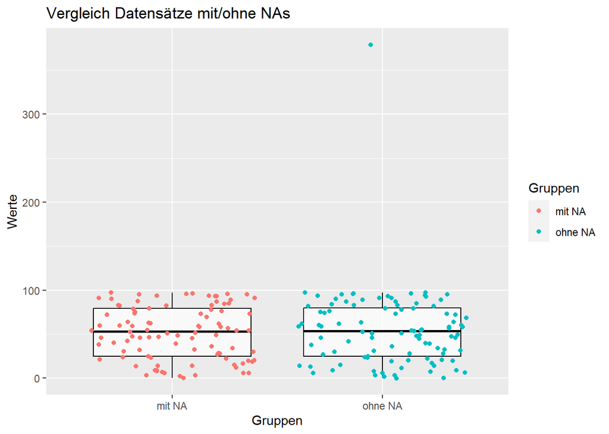

```r
# Umformatierung des Datensatzes zu Faktoren, sodass darstellbar durch ggplot
datensatz_plot_ohneNA <- data.frame(Werte = round(datensatz_missingValues$var_ohneNA))
datensatz_plot_ohneNA$Gruppen <- "ohne NA"
datensatz_plot_mitNA <- data.frame(Werte = round(datensatz_missingValues$var_mitNA))
datensatz_plot_mitNA$Gruppen <- "mit NA"
datensatz_plot <- rbind(datensatz_plot_ohneNA, datensatz_plot_mitNA)
datensatz_plot$Gruppen <- as.factor(datensatz_plot$Gruppen)

# Erstellung eines Stripcharts + Boxplot
ggplot(datensatz_plot, aes(x = Gruppen, y = Werte, color = Gruppen)) +
  geom_boxplot(outlier.shape = NA, color = "black", alpha = 0.7) +
  geom_jitter() +
  labs(title = "Vergleich Datensätze mit/ohne NAs")
```

#### **5. Leiten Sie aus diesen Ergebnisse Empfehlungen für den Umgang mit fehlenden Werten ab!**

NA-Werte in Datensätze sind keine Seltenheit. Daher sollte ein Datensatz vor jeder Asuwertung hinsichtlich NAs überprüft werden.  
Falls notwendig, sollten diese dann entfernt werden. Wird die Analyse auch dadurch gestört, so können die NA-Werte alternativ durch randomisierte Minimalwerte des Ausgangsdatensatzes ersetzet werden.

## Aufgabe C - Statistisches Testen

Der Biomarker X1053_at weist den kleinsten p-Wert auf. Im Boxplot wird deutlich, dass Patient:innen mit Grad 1 geringere Werte als Patienten mit Grad 3 Tumor aufweisen.

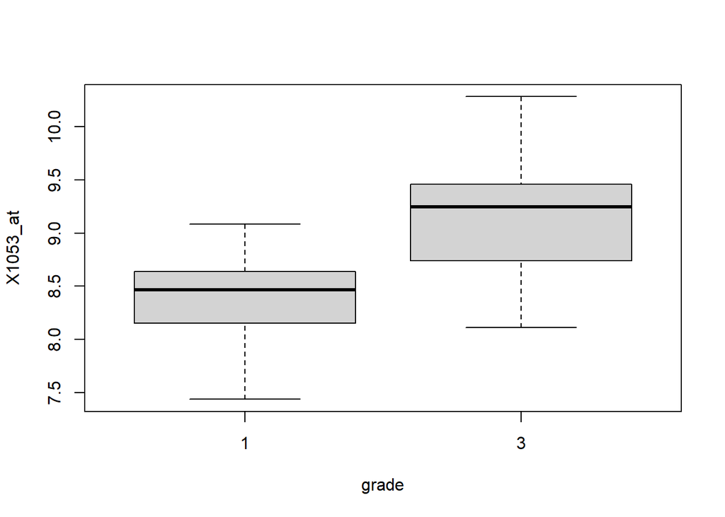

#### **1. Wo würden Sie den Cutpointsetzen?**

Der Cutpoint sollte die beiden Gruppen möglichst gleichmäßig aufteilen. Er sollte daher bei ca. 8.75 liegen. Für die Bestimmung eines möglichst genauen Cutpoint können auch Algorithmen verwendet werden.

#### **2. Dichotomisieren Sie den Biomarker anhand des Cutpoints!**

Zur nicht-subjektiven Bestimmung des Cutpoints wird der K-Means-Algorithmus verwendet (`kmeans()`). Anhand eines Stripcharts (`ggplot()`) wird die Gruppierung Visualisiert:

```r
# Dichotomisierung mittels kmeans
cutpoint_kmeans <- kmeans(daten_biomarker$X1053_at, 2, iter.max = 20)
cutpoint_kmeans
```

```
## K-means clustering with 2 clusters of sizes 34, 30
##
## Cluster means:
##       [,1]
## 1 8.297319
## 2 9.327440
##
## Clustering vector:
##  [1] 1 1 2 1 1 1 2 2 1 1 1 2 1 2 1 2 2 2 2 2 1 2 1 2 1 2 1 1 1 1 2 2 1 2 2 1 2 2
## [39] 1 2 2 1 1 1 1 2 2 2 1 2 2 2 1 1 1 2 1 1 1 1 1 1 2 2
##
## Within cluster sum of squares by cluster:
## [1] 3.986062 3.515485
##  (between_SS / total_SS =  69.3 %)
##
## Available components:
##
## [1] "cluster"      "centers"      "totss"        "withinss"     "tot.withinss"
## [6] "betweenss"    "size"         "iter"         "ifault"
```

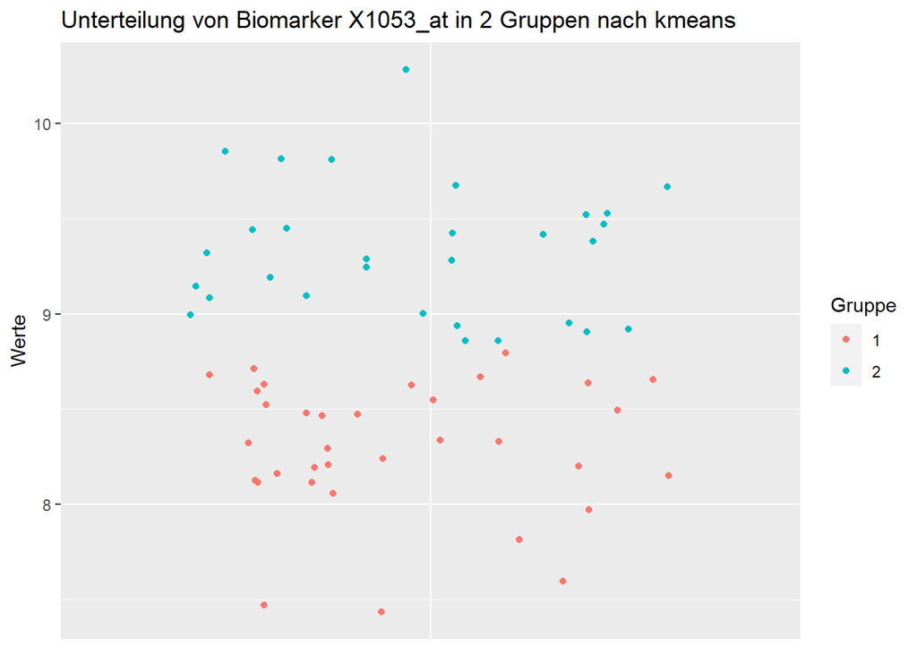

```r
# Visualisierung der beiden Gruppen
cutpoint_plot <- data.frame(Gruppe = as.factor(cutpoint_kmeans$cluster), Werte = daten_biomarker$X1053_at)
ggplot(cutpoint_plot, aes(x = factor(0), Werte, color = Gruppe)) +
  geom_jitter() +
  theme(axis.title.x = element_blank(), axis.text.x = element_blank(),axis.ticks.x = element_blank()) +
  labs(title = "Unterteilung von Biomarker X1053_at in 2 Gruppen nach kmeans")
```

Dem Graph ist eindeutig zu entnehmen, dass die Gruppierung erfolgreich war. Die Werte sind ca. um 8,75 herum aufgeteilt.

#### **3. Mit welchem Test / Konfidenzintervall kann man überprüfen, ob es einen Zusammenhang zwischen dem**

#### **dichotomisierten Biomarker und dem Grad der Patientinnen gibt?**

Hier handelt es sich um eine bivariate Analyse zweier **qualitativen** Variablen. Da beide nur zwei Werte annehmen können (-> binär) eignet sich hier der *Fisher’s Exact Test*. Könnten einer der beiden Gruppen mehr als 2 Ausprägungen annehmen, käme der Pearson’s Chi-Quadrat Test in Frage. Für eine Untersuchung mit Konfidenzintervall benötigte man einen KI für Ratendifferenz.

#### **4. Formulieren Sie die medizinischen und statistischen Hypothesen!**

- Medizinische Hypothesen:
  - $H_{0}$: Es gibt keinen Unterschied hinsichtlich der Messwerte von Biomarker X1053_at zwischen den Gruppen mit Grad 1 und Grad 3 Tumor.
  - $H_{1}$: Die beiden Gruppen weisen Unterschiede in den X1053_at-Messwerten auf.
- Statistische Hypothesen:
  - $H_{0}$: $\mu_{1} = \mu_{2}$
  - $H_{1}$: $\mu_{1} \neq \mu_{2}$

#### **5. Berechnen Sie die deskriptiven Statistiken und führen Sie den Test durch!**

```r
# Deskriptive Statistik
print("Gruppe 1 (Grad 1):")
summary(cutpoint_plot[cutpoint_plot$Gruppe == 1, 2])
print("Gruppe 2 (Grad 3):")
summary(cutpoint_plot[cutpoint_plot$Gruppe == 2, 2])
```

```
## [1] "Gruppe 1 (Grad 1):"
##    Min. 1st Qu.  Median    Mean 3rd Qu.    Max.
##   7.436   8.131   8.324   8.297   8.581   8.796
## [1] "Gruppe 2 (Grad 3):"
##    Min. 1st Qu.  Median    Mean 3rd Qu.    Max.
##   8.858   9.022   9.305   9.327   9.509  10.284
```

Erwartungsgemäß liegen das Mittel und der Median von Gruppe 1 unter Gruppe 3.

Die Vierfeldertafel vom dichotomisierten Biomarker und vom Tumorgrad sieht folgendermaßen aus:

```r
cutpoint_vierfeld_df <- data.frame(Gruppe = cutpoint_plot$Gruppe)
cutpoint_vierfeld_df$grade <- daten_biomarker$grade
cutpoint_vierfeld <- table(cutpoint_vierfeld_df)
cutpoint_vierfeld
```

```
##       grade
## Gruppe  1  3
##      1 24 10
##      2  5 25
```

Der Fisher’s Exact Test liefert dementsprechend:

```r
fisher.test(cutpoint_vierfeld)
```

```
##
##  Fisher's Exact Test for Count Data
##
## data:  cutpoint_vierfeld
## p-value = 1.664e-05
## alternative hypothesis: true odds ratio is not equal to 1
## 95 percent confidence interval:
##   3.159621 49.810398
## sample estimates:
## odds ratio
##   11.43551
```

#### **6. Treffen Sie eine Testentscheidung und interpretieren Sie Ihr Ergebnis!**

Mit einem p-Wert von $p = 1.664e-05$ ist das Ergebnis des Fisher’s Exact Test deutlich signifikant. Daher lässt sich die Nullhypothese $H_{0}$ verwerfen. Es lässt sich somit sagen, dass es eine Beziehung zwischen Biomarker X1053_at und dem Tumorgrad eines:r Patient:in gibt. Für eine weitere Untersuchung wäre das Effektmaß von Interesse.

## **Aufgabe D - Fallzahlplanung**

#### **Kontext:**

Für eine Studie zum Vergleich von zwei blutdrucksenkenden Medikamenten A und B werden durch Randomisierung der Studienteilnehmer:innen – also zufälliger Zuweisung der Patient:innen in die Therapiegruppen – zwei homogene und unabhängige Gruppen gebildet. Die Patient:innen der ersten Gruppe erhalten Medikament A, die der zweiten Gruppe erhalten Medikament B.  
Die mittlere Senkung des Blutdrucks nach vier Wochen sei der primäre Endpunkt.  
Aus Literaturstudien weiß man, dass die Senkung des Blutdrucks in der Population der Hypertoniker unter beiden Medikamenten als normalverteilt angenommen werden kann und dass das Medikament A den Blutdruck von Hypertonikern im Mittel um etwa 10mmHg senkt. Aufgrund bisheriger Untersuchungen wird bei Medikament B eine stärkere Senkung von etwa 15mmHg erwartet. Dies wird als eine relevante Verbesserung angesehen. Darüber hinaus wird für beide Medikamente aufgrund medizinischer Einschätzung eine Standardabweichung von 5mmHg bei der Blutdrucksenkung unterstellt.  
Es soll die Frage geklärt werden, ob zwischen Medikament A und Medikament B ein statistisch signifikanter Unterschied bei der Senkung des Blutdrucks besteht. Um weder zu wenige, noch zu viele Patient:innen in die Studie einzuschließen, wird eine Fallzahlplanung durchgeführt.

#### **1. Für welchen statistischen Test sollte bei dem oben genannten Studiendesign die Fallzahl geplant werden?**

Die Studie sollte am Ende durch einen unabhängigen, zweiseitigen (Student’s) t-Test kontrolliert werden. Dementsprechend sollte auch die Fallzahlplanung durchgeführt werden. So ergibt sich die Formel $n \ge 2(\frac{\sigma}{\Delta})^{2}(t_{df,1-\alpha/2}+t_{df,1-\beta})^{2}$.

#### **2. Welche Fallzahl ergibt sich für eine Güte/Power von 80% und ein zweiseitiges Signifikanzniveau von 5%?**

Untersuchung mittels zweiseitigen 2-Stichproben-t-Test:

```r
power.t.test(delta = 5, sd = 5, sig.level = 0.05, power = 0.8, type = "two.sample", alternative = "two.sided")
```

```
##
##      Two-sample t test power calculation
##
##               n = 16.71477
##           delta = 5
##              sd = 5
##       sig.level = 0.05
##           power = 0.8
##     alternative = two.sided
##
## NOTE: n is number in *each* group
```

Für eine Güte von 80% und einem zweiseitigen Signifikanzniveau (5%) ergibt sich eine Fallzahl von je mind. 17 Personen pro Gruppe (zuzüglich eines Drop-Out-Puffers).

#### **3. Welche Fallzahl ergibt sich für eine Güte/Power von 90% und ein zweiseitiges Signifikanznivea von 5%?**

Untersuchung mittels zweiseitigen 2-Stichproben-t-Test:

```r
power.t.test(delta = 5, sd = 5, sig.level = 0.05, power = 0.9, type = "two.sample", alternative = "two.sided")
```

```
##
##      Two-sample t test power calculation
##
##               n = 22.0211
##           delta = 5
##              sd = 5
##       sig.level = 0.05
##           power = 0.9
##     alternative = two.sided
##
## NOTE: n is number in *each* group
```

Für eine Güte von 90% und einem zweiseitigen Signifikanzniveau (5%) ergibt sich eine Fallzahl von je mind. 23 Personen pro Gruppe.

#### **4. Die Logistik der Studie begrenzt die Fallzahl auf n = 10 pro Gruppe. Wie groß wäre die Güte/Power mit den oben genannten Annahmen für diese festgelegte Fallzahl (bei zweiseitigem Signifikanzniveau von 5%)?**

```r
power.t.test(n = 10, delta = 5, sd = 5, sig.level = 0.05, type = "two.sample", alternative = "two.sided")
```

```
##
##      Two-sample t test power calculation
##
##               n = 10
##           delta = 5
##              sd = 5
##       sig.level = 0.05
##           power = 0.5619846
##     alternative = two.sided
##
## NOTE: n is number in *each* group
```

Für eine Fallzahl von n = 10 und einem zweiseitigen Signifikanzniveau (5%) ergeibt sich eine Güte von ca. 56%.

#### **5. Statt der Feststellung eines statistisch signifikanten Unterschiedes zwischen den beiden Medikamenten soll jetzt nur die Frage geklärt werden, ob Medikament B den Blutdruck stärker senkt als Medikament A. Was ändert sich durch diese Fragestellung am Studiendesign und ändert sich hierdurch auch die Fallzahl?**

Prinzipiell bleibt die Studiendurchführung allgemein die Gleiche. Die Teststatisitk ändert sich allerdings zu einem *einseitigen* t-Test. Da nun derselbe 5% Typ-1-Fehler einseitig konzentriert ist (anstelle von 2,5% augrund der Aufteilung), genügt zur Feststellung einer statistischen Signifikanz bereits eine geringere Fallzahl, s. Formel: $n \ge 2(\frac{\sigma}{\Delta})^{2}(t_{df,1-\alpha}+t_{df,1-\beta})^{2}$.

Bei erneuter Berechnung mit einer Güte von 80% und einem Typ-1-Fehler von 5% ergibt der einseitige t-Test folgendes:

```r
power.t.test(delta = 5, sd = 5, sig.level = 0.05, power = 0.8, type = "two.sample", alternative = "one.sided")
```

```
##
##      Two-sample t test power calculation
##
##               n = 13.09777
##           delta = 5
##              sd = 5
##       sig.level = 0.05
##           power = 0.8
##     alternative = one.sided
##
## NOTE: n is number in *each* group
```

Die Mindesfallzahl pro Gruppe beträgt nun anstelle von 17 Teilnehmern 14 Teilnehmer (Güte: 80%).

Und:

```r
power.t.test(delta = 5, sd = 5, sig.level = 0.05, power = 0.9, type = "two.sample", alternative = "one.sided")
```

```
##
##      Two-sample t test power calculation
##
##               n = 17.84713
##           delta = 5
##              sd = 5
##       sig.level = 0.05
##           power = 0.9
##     alternative = one.sided
##
## NOTE: n is number in *each* group
```

Für die Güte von 90% reduziert sich die Fallzahl pro Gruppe von 23 Personen auf 18 Personen.

- Mehr zum Thema: [Wie Statistik in den Nachichten behandelt wird (engl.)](https://www.youtube.com/watch?v=xfr64zoBTAQ) (Videobeitrag)